# hw3

Shike Zhang

2024-10-13

## Problem 1

- The `ny_noaa` dataset contains weather data for New York State. It includes observations from several stations over multiple years. The dataset consists of variables such as `tmax`, `tmin`, `snow`, and `precipitation`.
- Missing data is present in many of the variables, especially for temperature and snowfall observations.

```r
library(tidyverse)
```

```r
library(lubridate)
library(ggridges)
library(ggplot2)
```

```r
library(p8105.datasets)
data("ny_noaa")
head(ny_noaa, n= 10)
```

```
## # A tibble: 10 × 7
##    id          date        prcp  snow  snwd tmax  tmin
##    <chr>       <date>     <int> <int> <int> <chr> <chr>
##  1 US1NYAB0001 2007-11-01    NA    NA    NA <NA>  <NA>
##  2 US1NYAB0001 2007-11-02    NA    NA    NA <NA>  <NA>
##  3 US1NYAB0001 2007-11-03    NA    NA    NA <NA>  <NA>
##  4 US1NYAB0001 2007-11-04    NA    NA    NA <NA>  <NA>
##  5 US1NYAB0001 2007-11-05    NA    NA    NA <NA>  <NA>
##  6 US1NYAB0001 2007-11-06    NA    NA    NA <NA>  <NA>
##  7 US1NYAB0001 2007-11-07    NA    NA    NA <NA>  <NA>
##  8 US1NYAB0001 2007-11-08    NA    NA    NA <NA>  <NA>
##  9 US1NYAB0001 2007-11-09    NA    NA    NA <NA>  <NA>
## 10 US1NYAB0001 2007-11-10    NA    NA    NA <NA>  <NA>
```

Do some data cleaning. Create separate variables for year, month, and day. Ensure observations for temperature, precipitation, and snowfall are given in reasonable units. For snowfall, what are the most commonly observed values? Why?

```r
# Clean the data
ny_noaa_clean <- ny_noaa %>%
  mutate(
    year = year(date),
    month = month(date),
    day = day(date),
    # Ensure reasonable units for temperature and precipitation
    tmax = as.numeric(tmax) / 10, # Assuming tmax is in tenths of degree Celsius
    tmin = as.numeric(tmin) / 10,
    snow = as.numeric(snow), # tenths of millimeters
    prcp = as.numeric(prcp)# tenths of millimeters
  ) %>%
  filter(!is.na(tmax), !is.na(tmin), !is.na(snow))

head(ny_noaa_clean,n=10)
```

```
## # A tibble: 10 × 10
##    id          date        prcp  snow  snwd  tmax  tmin  year month   day
##    <chr>       <date>     <dbl> <dbl> <int> <dbl> <dbl> <dbl> <dbl> <int>
##  1 USC00300023 1981-01-03     0     0     0 -12.2 -20.6  1981     1     3
##  2 USC00300023 1981-01-05     0     0     0  -5.6 -17.8  1981     1     5
##  3 USC00300023 1981-01-12     0     0     0 -12.2 -30.6  1981     1    12
##  4 USC00300023 1981-01-13     0     0     0  -6.7 -28.9  1981     1    13
##  5 USC00300023 1981-01-15     0     0     0  -5   -10.6  1981     1    15
##  6 USC00300023 1981-01-17     0     0     0  -1.1 -15    1981     1    17
##  7 USC00300023 1981-01-20     0     0     0   6.1  -6.7  1981     1    20
##  8 USC00300023 1981-01-21     0     0     0   1.7 -10.6  1981     1    21
##  9 USC00300023 1981-01-22     0     0     0   0.6  -5    1981     1    22
## 10 USC00300023 1981-01-23   117   127    76   2.2  -4.4  1981     1    23
```

```r
# Commonly observed snowfall values
snow_values <- ny_noaa_clean %>%
  group_by(snow) %>%
  summarise(count = n()) %>%
  arrange(desc(count))

head(snow_values, n=10)
```

```
## # A tibble: 10 × 2
##     snow   count
##    <dbl>   <int>
##  1     0 1167149
##  2    25   17542
##  3    13   13704
##  4    51   10352
##  5     5    5960
##  6    76    5894
##  7     8    5777
##  8     3    5614
##  9    38    5578
## 10   102    3743
```

Make a two-panel plot showing the average max temperature in January and in July in each station across years. Is there any observable / interpretable structure? Any outliers?

```r
# Filter for January and July, group by station, year, and month, and compute mean tmax
jan_july_tmax <- ny_noaa_clean %>%
  filter(month %in% c(1, 7)) %>%
  group_by(id, year, month) %>%
  summarise(mean_tmax = mean(tmax, na.rm = TRUE)) %>%
  ungroup()
```

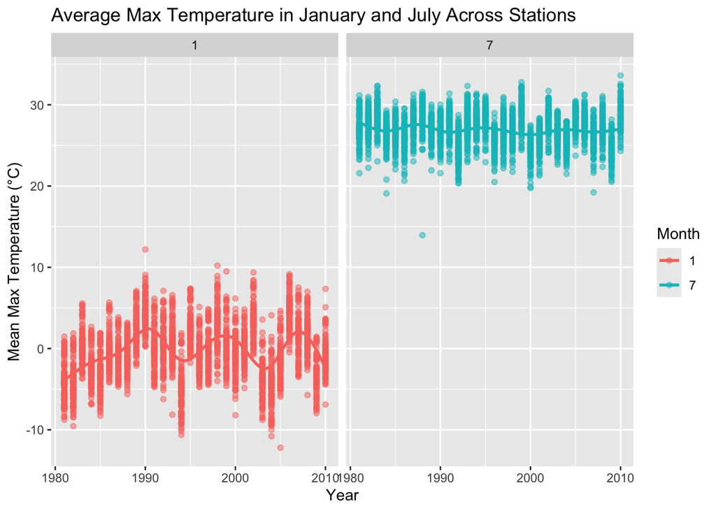

```r
ggplot(jan_july_tmax, aes(x = year, y = mean_tmax, color = factor(month))) +
  geom_point(alpha = 0.5) +
  geom_smooth(se = FALSE) +
  facet_wrap(.~ month) +
  labs(
    title = "Average Max Temperature in January and July Across Stations",
    x = "Year",
    y = "Mean Max Temperature (°C)",
    color = "Month"
  )
```

Make a two-panel plot showing (i) tmax vs tmin for the full dataset (note that a scatterplot may not be the best option); and (ii) make a plot showing the distribution of snowfall values greater than 0 and less than 100 separately by year.

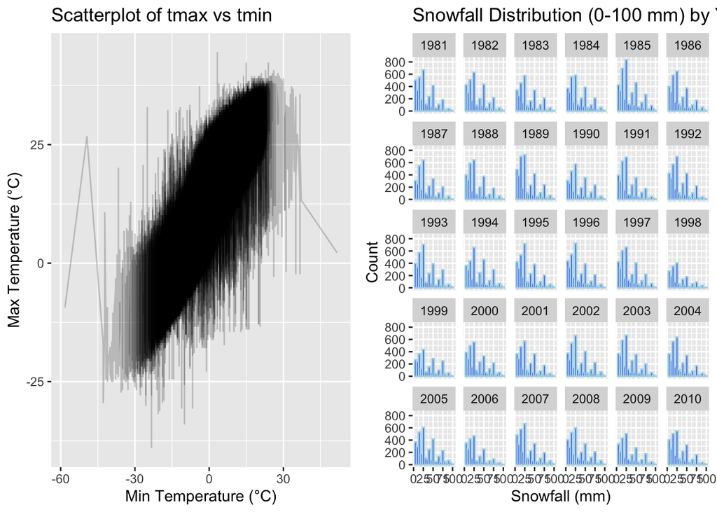

```r
# Scatterplot of tmax vs tmin
scatter_tmax_tmin <- ggplot(ny_noaa_clean, aes(x = tmin, y = tmax)) +
  geom_line(alpha = 0.2) +
  labs(
    title = "Scatterplot of tmax vs tmin",
    x = "Min Temperature (°C)",
    y = "Max Temperature (°C)"
  )

# Snowfall distribution for values between 0 and 100
snow_histogram <- ny_noaa_clean %>%
  filter(snow > 0, snow < 100) %>%
  ggplot(aes(x = snow)) +
  geom_histogram(binwidth = 5, fill = "blue", color = "lightblue") +
  facet_wrap(~ year) +
  labs(
    title = "Snowfall Distribution (0-100 mm) by Year",
    x = "Snowfall (mm)",
    y = "Count"
  )

# Display both plots side by side using gridExtra
gridExtra::grid.arrange(scatter_tmax_tmin, snow_histogram, ncol = 2)
```

## Problem 2

Load, tidy, merge, and otherwise organize the data sets. Your final dataset should include all originally observed variables; exclude participants less than 21 years of age, and those with missing demographic data; and encode data with reasonable variable classes (i.e. not numeric, and using factors with the ordering of tables and plots in mind).

```r
# Load necessary libraries
library(tidyverse)

# Load demographic and accelerometer data
covar_data <- read_csv("~/Desktop/DS HW/p8105_hw3_sz3318/data/nhanes_covar.csv")
```

```
## ──────────────────────────────────────────────────────── Delimiter: "," chr
## (5): ...1, 1 = male, ...3, ...4, 1 = Less than high school
```

```r
head(covar_data)
```

```
## # A tibble: 6 × 5
##   ...1  `1 = male` ...3  ...4  `1 = Less than high school`
##   <chr> <chr>      <chr> <chr> <chr>
## 1 <NA>  2 = female <NA>  <NA>  2 =  High school equivalent
## 2 <NA>  <NA>       <NA>  <NA>  3  = More than high school
## 3 <NA>  <NA>       <NA>  <NA>  <NA>
## 4 SEQN  sex        age   BMI   education
## 5 62161 1          22    23.3  2
## 6 62164 2          44    23.2  3
```

```r
accel_data <- read_csv("~/Desktop/DS HW/p8105_hw3_sz3318/data/nhanes_accel.csv")
head(accel_data)
```

```
## # A tibble: 6 × 1,441
##    SEQN  min1  min2  min3  min4   min5   min6  min7   min8    min9  min10  min11
##   <dbl> <dbl> <dbl> <dbl> <dbl>  <dbl>  <dbl> <dbl>  <dbl>   <dbl>  <dbl>  <dbl>
## 1 62161 1.11  3.12  1.47  0.938 1.60   0.145  2.10  0.509   1.63   1.20   0.947
## 2 62164 1.92  1.67  2.38  0.935 2.59   5.22   2.39  4.90    1.97   3.13   2.77
## 3 62169 5.85  5.18  4.76  6.48  6.85   7.24   6.12  7.48    5.47   6.49   5.14
## 4 62174 5.42  3.48  3.72  3.81  6.85   4.45   0.561 1.61    0.698  2.72   4.85
## 5 62177 6.14  8.06  9.99  6.60  4.57   2.78   7.10  7.25   10.1    7.49   2.72
## 6 62178 0.167 0.429 0.131 1.20  0.0796 0.0487 0.106 0.0653  0.0564 0.0639 0.0909
## # ℹ 1,429 more variables: min12 <dbl>, min13 <dbl>, min14 <dbl>, min15 <dbl>,
## #   min16 <dbl>, min17 <dbl>, min18 <dbl>, min19 <dbl>, min20 <dbl>,
## #   min21 <dbl>, min22 <dbl>, min23 <dbl>, min24 <dbl>, min25 <dbl>,
## #   min26 <dbl>, min27 <dbl>, min28 <dbl>, min29 <dbl>, min30 <dbl>,
## #   min31 <dbl>, min32 <dbl>, min33 <dbl>, min34 <dbl>, min35 <dbl>,
## #   min36 <dbl>, min37 <dbl>, min38 <dbl>, min39 <dbl>, min40 <dbl>,
## #   min41 <dbl>, min42 <dbl>, min43 <dbl>, min44 <dbl>, min45 <dbl>, …
```

```r
# Clean and tidy covar data
# Filter out participants under 21 and handle missing demographic data
covar_clean <- covar_data[-c(1:3), ]
colnames(covar_clean) = c("SEQN", "sex", "age", "BMI", "education")
covar_clean <- covar_clean[-1, ] # remove duplicate

#Convert to numeric
covar_clean$age <- as.numeric(covar_clean$age)
covar_clean$BMI <- as.numeric(covar_clean$BMI)

# Convert sex and education to factors
covar_clean$sex <- factor(covar_clean$sex, levels = c("1", "2"), labels = c("Male", "Female"))

# For education, assume: 1 = Less than high school, 2 = High school equivalent, 3 = More than high school
covar_clean$education <- factor(covar_clean$education,
                               levels = c("1", "2", "3"),
                               labels = c("Less than high school", "High school equivalent", "More than high school"),
                               ordered = TRUE)

covar_clean <- covar_clean %>%
  filter(age>21) %>%
  drop_na() %>%
  arrange(age)

str(covar_clean)
```

```
## tibble [225 × 5] (S3: tbl_df/tbl/data.frame)
##  $ SEQN     : chr [1:225] "62161" "62214" "62239" "62332" ...
##  $ sex      : Factor w/ 2 levels "Male","Female": 1 2 2 1 1 1 1 1 2 1 ...
##  $ age      : num [1:225] 22 22 22 22 22 22 22 23 23 23 ...
##  $ BMI      : num [1:225] 23.3 23.8 23.3 32.6 30.2 25.8 23.2 33 38 26.7 ...
##  $ education: Ord.factor w/ 3 levels "Less than high school"<..: 2 2 2 3 3 2 2 1 3 3 ...
```

```r
head(covar_clean,n=10)
```

```
## # A tibble: 10 × 5
##    SEQN  sex      age   BMI education
##    <chr> <fct>  <dbl> <dbl> <ord>
##  1 62161 Male      22  23.3 High school equivalent
##  2 62214 Female    22  23.8 High school equivalent
##  3 62239 Female    22  23.3 High school equivalent
##  4 62332 Male      22  32.6 More than high school
##  5 62440 Male      22  30.2 More than high school
##  6 62475 Male      22  25.8 High school equivalent
##  7 62584 Male      22  23.2 High school equivalent
##  8 62301 Male      23  33   Less than high school
##  9 62349 Female    23  38   More than high school
## 10 62383 Male      23  26.7 More than high school
```

```r
# Tidy, clean accel dataset
# Ensure MIMS column (if it exists) is numeric, and remove rows with missing values
accel_clean <- accel_data %>%
  pivot_longer(
    col = "min1":"min1440",
    names_to = "mins_num",
    values_to = "mins") %>%
    mutate(mins = as.numeric(mins)) %>%
    drop_na()

head(accel_clean)
```

```
## # A tibble: 6 × 3
##    SEQN mins_num  mins
##   <dbl> <chr>    <dbl>
## 1 62161 min1     1.11
## 2 62161 min2     3.12
## 3 62161 min3     1.47
## 4 62161 min4     0.938
## 5 62161 min5     1.60
## 6 62161 min6     0.145
```

Final Dataset

```r
# Merge accelerometer data with covariate data using SEQN
final_data <- merge(covar_clean, accel_clean, by = "SEQN")
head(final_data,n=10)
```

```
##     SEQN  sex age  BMI              education mins_num      mins
## 1  62161 Male  22 23.3 High school equivalent   min490 23.532167
## 2  62161 Male  22 23.3 High school equivalent   min594 24.082500
## 3  62161 Male  22 23.3 High school equivalent   min595 22.762667
## 4  62161 Male  22 23.3 High school equivalent   min475 19.930667
## 5  62161 Male  22 23.3 High school equivalent   min872 14.291500
## 6  62161 Male  22 23.3 High school equivalent   min514 16.601667
## 7  62161 Male  22 23.3 High school equivalent   min503 11.457833
## 8  62161 Male  22 23.3 High school equivalent   min489 16.148333
## 9  62161 Male  22 23.3 High school equivalent   min485  5.204667
## 10 62161 Male  22 23.3 High school equivalent   min486  7.629333
```

Produce a reader-friendly table for the number of men and women in each education category, and create a visualization of the age distributions for men and women in each education category. Comment on these items.

```r
library(knitr)
#Create a table of men and women in each education category
gender_education_table <- covar_clean %>%
  group_by(education, sex) %>%
  summarise(count = n()) %>%
  spread(sex, count, fill = 0)
gender_education_table %>%
  kable(col.names = c("Education Level", "Male", "Female"), caption = "Number of Men and Women by Education Level")
```

Number of Men and Women by Education Level

| Education Level | Male | Female |
| --- | --- | --- |
| Less than high school | 27 | 28 |
| High school equivalent | 34 | 23 |
| More than high school | 54 | 59 |

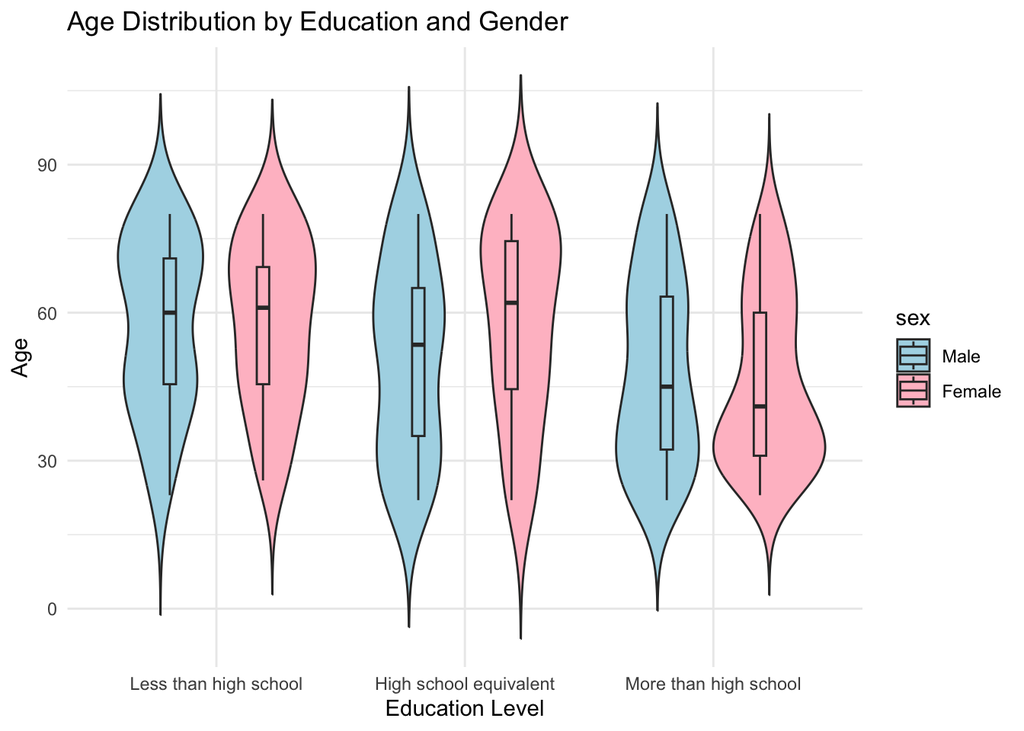

```r
# Visualize the age distributions for men and women in each education category
ggplot(covar_clean, aes(x = education, y = age, fill = sex)) +
  geom_violin(trim = FALSE) +
  geom_boxplot(width = 0.1, position = position_dodge(0.75), outlier.shape = NA) +
  labs(title = "Age Distribution by Education and Gender", x = "Education Level", y = "Age") +
  theme_minimal() +
  scale_fill_manual(values = c("Male" = "lightblue", "Female" = "pink"))
```

Traditional analyses of accelerometer data focus on the total activity over the day. Using your tidied dataset, aggregate across minutes to create a total activity variable for each participant. Plot these total activities (y-axis) against age (x-axis); your plot should compare men to women and have separate panels for each education level. Include a trend line or a smooth to illustrate differences. Comment on your plot.

```r
# Aggregate total activity for each participant
total_activity <- final_data %>%
  group_by(SEQN, sex, age, education) %>%
  summarise(total_activity = sum(mins, na.rm = TRUE))
# Check the summary of the total activity data
summary(total_activity)
```

```
##      SEQN               sex           age                         education
##  Length:225         Male  :115   Min.   :22.00   Less than high school : 55
##  Class :character   Female:110   1st Qu.:35.00   High school equivalent: 57
##  Mode  :character                Median :50.00   More than high school :113
##                                  Mean   :50.88
##                                  3rd Qu.:67.00
##                                  Max.   :80.00
##  total_activity
##  Min.   :  301.3
##  1st Qu.:10091.0
##  Median :12859.0
##  Mean   :12819.1
##  3rd Qu.:15724.3
##  Max.   :22225.8
```

```r
head(total_activity,n=10)
```

```
## # A tibble: 10 × 5
## # Groups:   SEQN, sex, age [10]
##    SEQN  sex      age education              total_activity
##    <chr> <fct>  <dbl> <ord>                           <dbl>
##  1 62161 Male      22 High school equivalent         13194.
##  2 62164 Female    44 More than high school          13411.
##  3 62174 Male      80 More than high school           8579.
##  4 62177 Male      51 High school equivalent         11918.
##  5 62178 Male      80 High school equivalent          7489.
##  6 62180 Male      35 More than high school          14205.
##  7 62184 Male      26 High school equivalent         13599.
##  8 62189 Female    30 More than high school          18551.
##  9 62199 Male      57 More than high school          14548.
## 10 62202 Male      36 Less than high school          16368.
```

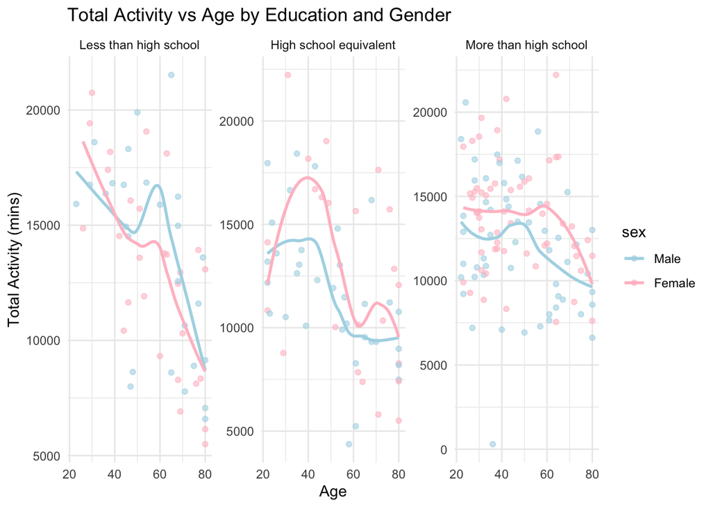

```r
ggplot(total_activity, aes(x = age, y = total_activity, color = sex)) +
  geom_point(alpha = 0.6) +  # Add scatter points
  geom_smooth(method = "loess", se = FALSE) +  # Add smooth trend line
  facet_wrap(~ education, scales = "free_y") +  # Separate panels for education levels
  labs(title = "Total Activity vs Age by Education and Gender",
       x = "Age",
       y = "Total Activity (mins)") +
  theme_minimal() +
  scale_color_manual(values = c("Male" = "lightblue", "Female" = "pink"))
```

Accelerometer data allows the inspection activity over the course of the day. Make a three-panel plot that shows the 24-hour activity time courses for each education level and use color to indicate sex. Describe in words any patterns or conclusions you can make based on this graph; including smooth trends may help identify differences.

```r
# Calculate the average activity at each time point (minute) across the 24-hour period
average_activity <- final_data %>%
  group_by(mins_num, education, sex) %>%
  summarise(mean_activity = mean(mins, na.rm = TRUE))
head(average_activity,n=10)
```

```
## # A tibble: 10 × 4
## # Groups:   mins_num, education [5]
##    mins_num education              sex    mean_activity
##    <chr>    <ord>                  <fct>          <dbl>
##  1 min1     Less than high school  Male            5.31
##  2 min1     Less than high school  Female          3.52
##  3 min1     High school equivalent Male            4.97
##  4 min1     High school equivalent Female          3.64
##  5 min1     More than high school  Male            3.87
##  6 min1     More than high school  Female          3.87
##  7 min10    Less than high school  Male            5.26
##  8 min10    Less than high school  Female          3.06
##  9 min10    High school equivalent Male            4.61
## 10 min10    High school equivalent Female          3.54
```

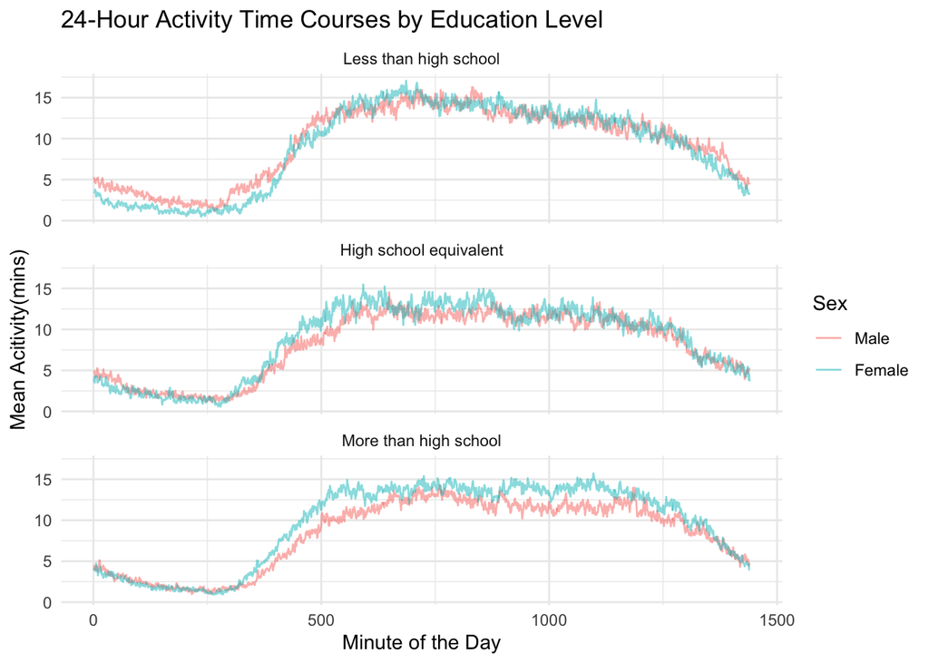

```r
# Extract the numeric minute from the 'mins_num' column
average_activity$mins_num <- as.numeric(gsub("min", "", average_activity$mins_num))

# Create the three-panel plot
ggplot(average_activity, aes(x = mins_num, y = mean_activity, color = sex)) +
  geom_line(alpha = 0.5) +
  facet_wrap(~ education, ncol = 1) +
  labs(title = "24-Hour Activity Time Courses by Education Level",
       x = "Minute of the Day",
       y = "Mean Acitivity(mins)",
       color = "Sex") +
  theme_minimal()
```

- Conclusion: Across all education levels, there is a noticeable daily activity pattern where activity levels start low at midnight, gradually increase in the morning, peak around midday, and then slowly decline in the evening. The trends are relatively similar regardless of education level, indicating a typical diurnal activity pattern shared by participants.
- Participants with “Less than high school” education tend to have slightly higher activity levels during the morning and midday compared to other groups. “More than high school” and “High school equivalent” education levels show more moderate activity levels throughout the day, with the peak activity being comparable across the three groups.

## Problem 3

Produce a reader-friendly table showing the total number of rides in each combination of year and month separating casual riders and Citi Bike members. Comment on these results.

```r
# Load necessary libraries
library(tidyverse)
library(lubridate)

# Read the CSV files
jan_2020 <- read_csv("~/Desktop/DS HW/p8105_hw3_sz3318/data/citibike/Jan 2020 Citi.csv")
july_2020 <- read_csv("~/Desktop/DS HW/p8105_hw3_sz3318/data/citibike/July 2020 Citi.csv")
jan_2024 <- read_csv("~/Desktop/DS HW/p8105_hw3_sz3318/data/citibike/Jan 2024 Citi.csv")
july_2024 <- read_csv("~/Desktop/DS HW/p8105_hw3_sz3318/data/citibike/July 2020 Citi.csv")
# Add 'year' and 'month' columns
jan_2020 <- jan_2020 %>% mutate(year = 2020, month = "January")
july_2020 <- july_2020 %>% mutate(year = 2020, month = "July")
jan_2024 <- jan_2024 %>% mutate(year = 2024, month = "January")
july_2024 <- july_2024 %>% mutate(year = 2024, month = "July")

# Combine all the data
combined_df <- bind_rows(jan_2020, july_2020, jan_2024, july_2024)
head(combined_df,n=10)
```

```
## # A tibble: 10 × 9
##    ride_id   rideable_type weekdays duration start_station_name end_station_name
##    <chr>     <chr>         <chr>       <dbl> <chr>              <chr>
##  1 4BE06CB3… classic_bike  Tuesday     15.3  Columbus Ave & W … E 53 St & Madis…
##  2 26886E03… classic_bike  Wednesd…     5.31 2 Ave & E 96 St    1 Ave & E 110 St
##  3 24DC5606… classic_bike  Friday       9.69 Columbia St & Riv… Grand St & Eliz…
##  4 EEDC1053… classic_bike  Sunday       7.00 W 84 St & Columbu… Columbus Ave & …
##  5 2CD4BD4C… classic_bike  Friday       2.85 Forsyth St & Broo… Suffolk St & St…
##  6 E18682F9… classic_bike  Sunday      25.5  Allen St & Hester… Atlantic Ave & …
##  7 B9B2E896… classic_bike  Sunday       3.65 Lafayette St & Je… Washington Pl &…
##  8 DEF8F504… classic_bike  Sunday      38.3  28 Ave & 44 St     Broadway & Kosc…
##  9 17D44DA9… classic_bike  Thursday    38.5  Barrow St & Hudso… Emerson Pl & My…
## 10 0FD113A3… classic_bike  Tuesday      6.52 Carlton Ave & Par… Emerson Pl & My…
## # ℹ 3 more variables: member_casual <chr>, year <dbl>, month <chr>
```

```r
# Summarize the total number of rides by year, month, and member_casual
ride_counts <- combined_df %>%
  group_by(year, month, member_casual) %>%
  summarise(total_rides = n())
# View the table
head(ride_counts,n=10)
```

```
## # A tibble: 8 × 4
## # Groups:   year, month [4]
##    year month   member_casual total_rides
##   <dbl> <chr>   <chr>               <int>
## 1  2020 January casual                984
## 2  2020 January member              11436
## 3  2020 July    casual               5637
## 4  2020 July    member              15411
## 5  2024 January casual               2108
## 6  2024 January member              16753
## 7  2024 July    casual               5637
## 8  2024 July    member              15411
```

Make a table showing the 5 most popular starting stations for July 2024; include the number of rides originating from these stations.

```r
# Filter the data for July 2024
top_stations_july_2024 <- july_2024 %>%
  group_by(start_station_name) %>%
  summarise(num_rides = n()) %>%
  arrange(desc(num_rides)) %>%
  slice_head(n = 5)

# View the top 5 starting stations
head(top_stations_july_2024,n=10)
```

```
## # A tibble: 5 × 2
##   start_station_name            num_rides
##   <chr>                             <int>
## 1 12 Ave & W 40 St                    140
## 2 W 21 St & 6 Ave                     116
## 3 1 Ave & E 68 St                     114
## 4 West St & Chambers St               114
## 5 Christopher St & Greenwich St       110
```

Make a plot to investigate the effects of day of the week, month, and year on median ride duration. This plot can include one or more panels, but should facilitate comparison across all variables of interest. Comment on your observations from this plot.

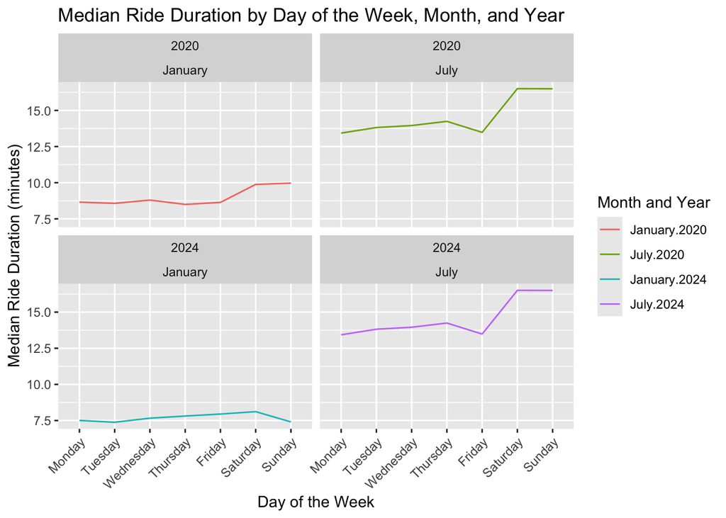

```r
# Plot the Effect of Day of the Week, Month, and Year on Median Ride Duration
# Summarize the median duration by year, month, and weekdays
median_duration <- combined_df %>%
  group_by(year, month, weekdays) %>%
  summarise(median_duration = median(duration, na.rm = TRUE))
# Convert weekdays to ordered factor to ensure correct plotting order
median_duration <- median_duration %>%
  mutate(weekdays = factor(weekdays, levels = c("Monday", "Tuesday", "Wednesday", "Thursday", "Friday", "Saturday", "Sunday")))

# Create the faceted plot
ggplot(median_duration, aes(x = weekdays, y = median_duration, group = interaction(month, year), color = interaction(month, year))) +
  geom_line() +
  facet_wrap(~ year + month, ncol = 2) +
  labs(title = "Median Ride Duration by Day of the Week, Month, and Year",
       x = "Day of the Week", y = "Median Ride Duration (minutes)",
       color = "Month and Year") +
  theme(axis.text.x = element_text(angle = 45, hjust = 1))
```

There were relatively few electric Citi Bikes in 2020, but many more are available now. For data in 2024, make a figure that shows the impact of month, membership status, and bike type on the distribution of ride duration. Comment on your results.

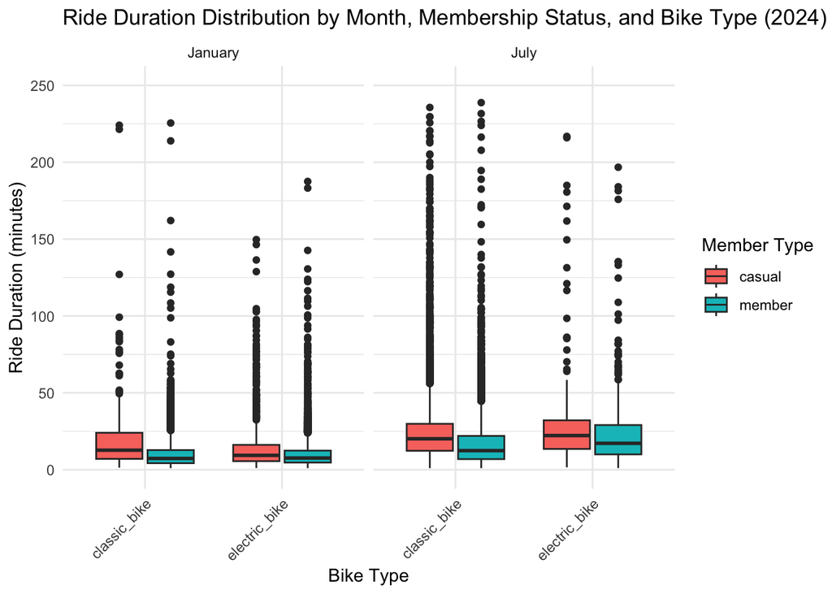

```r
# Filter the data for 2024
df_2024 <- combined_df %>% filter(year == 2024)

# Create a boxplot to show the distribution of ride duration by month, membership status, and bike type
ggplot(df_2024, aes(x = rideable_type, y = duration, fill = member_casual)) +
  geom_boxplot() +
  facet_wrap(~ month) +
  labs(title = "Ride Duration Distribution by Month, Membership Status, and Bike Type (2024)",
       x = "Bike Type", y = "Ride Duration (minutes)", fill = "Member Type") +
  theme_minimal() +
  theme(axis.text.x = element_text(angle = 45, hjust = 1)) +
  scale_y_continuous(limits = c(0, 250), oob = scales::squish) # Limits to handle outliers
```